# Software

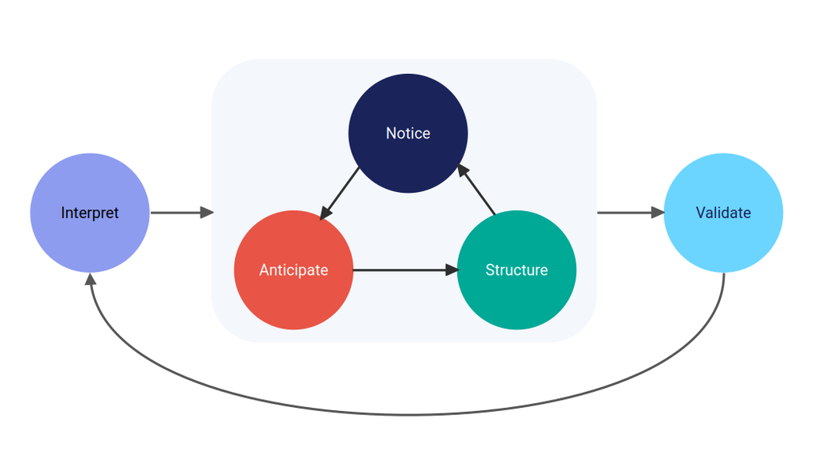

### Behavioral Insight Design (BID): A Framework for Cognitive-Aware Dashboard Development

Software Development

User Experience

Research

Introduction of the BID framework and bidux R package for designing dashboards with cognitive psychology principles.

Jun 1, 2025

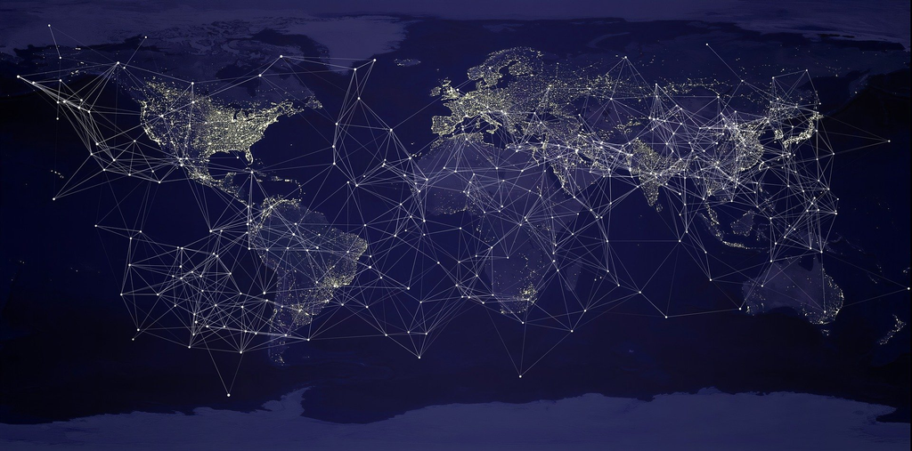

### PSYC 100 - Psychological Perspectives on the Experiences of Globalization

An undergraduate-level course on understanding issues related to globalization through psychological theory and research.

Education

Psychology

Exploring globalization through psychological concepts, research, and theory with real-world applications.

Aug 30, 2021

### PSYC 280 - Judgment and Decision Making

An undergraduate-level course on understanding judgment and decision-making through psychological theory and research.

Education

Psychology

State-of-the-art discussion of research on judgment and decision-making from psychological, philosophical, and economic perspectives.

Aug 30, 2021

### PSYC 306 - Research Methods

An undergraduate-level course on the fundamentals of research methods in the social sciences.

Education

Research

Introduction to research methods and statistics used in psychological research, including experimental and non-experimental methodologies.

Aug 30, 2021

### PSYC 360 - Understanding Prejudice

An undergraduate-level course that focuses on psychological research and theories that increase our understanding of stereotypes, prejudice, and intergroup relations.

Education

Psychology

Psychological research and theories on stereotypes, prejudice, and intergroup relations across various social groups.

Aug 30, 2021

### PSYC 304 - Statistics

An undergraduate-level course on the fundamentals of statistics and hypothesis testing.

Education

Data Science

Conceptual understanding of statistics, research methods, and data analysis for psychology students.

Jan 18, 2021